# Estimating Chronic Disease Disparity, Chicago Metro and CCDPH Jurisdiction

C. Scott Smith, PhD AICP

6/14/2021

# Background

This report maps the geographic patterning of chronic health conditions to identify disease hot spots and evaluate differences in outcomes by sociodemographic group within the greater Chicago region. The report finds: (1) that the spatial arrangement and magnitude of geographic clusters vary by category of disease; and (2) considerable disparities in health outcomes exist between racial, ethnic and economic groups both at the regional and subregional scales.

# Study areas

These seven counties were selected in part because they represent considerable diversity both in terms of urban design (e.g., including both higher-density urban centers as well as lower-density exurban communities) and sociodemographic makeup. The counties also correspond with the Chicago Metropolitan Agency for Planning’s (CMAP) planning area thereby allowing for ready integration of the metropolitan planning organization’s rich datasets and presenting opportunities for future research to be carried across CMAP’s jurisdiction. In addition to the regional analysis, we carry out a similar evaluation of disease and disparity within CCDPH’s jurisdiction which is wholly contained within Cook County.

[interactive chart not shown]

Chicago Metropolitan Region Study Area Boundary, Counties

# Data & methodology

We employ three publicly available datasets to carry out the study.

## CDC’s PLACES modeled chronic disease prevalence (link)

Centers for Disease Control and Prevention (CDC) PLACES dataset was used to model chronic disease across the study areas at the census tract level. The PLACES Project is an expansion of the original 500 Cities Project that began in 2015. The original project was launched by the Centers for Disease Control and Prevention (CDC) in partnership with the Robert Wood Johnson Foundation (RWJF) and CDC Foundation. In 2018, this partnership was extended through 2020. In 2020, the project expanded to provide small area estimates (SAE) for counties, places, census tracts, and ZIP Code Tabulation Areas (ZCTA) across the United States. The CDC uses a multilevel regression and poststratification (MRP) approach which links geocoded health surveys–specifically, the Behavioral Risk Factor Surveillance System (BRFSS)–with demographic and socioeconomic data made available in the American Community Survey (ACS) to estimate geographic distributions of population disease burden and health behaviors at the community level.

## ACS 5-year sociodemographic estimates (link)

The analysis uses ACS 5-year estimates of study area populations by age, race, ethnicity and income for standardizing prevalence measures across geographies and identifying health disparities by demographic group. The 5-year estimates used in this study represent data collected between 2015 and 2019, which allows for greater statistical reliability.

## TIGER/Line cartographic boundary data

Topologically Integrated Geographic Encoding and Referencing (TIGER) Database (MTDB) or TIGER/Line shapefiles of the study area were used to link geographies to data in both the ACS and PLACES at the census tract level. The geometries made it possible to estimate global and spatial autocorrelation across sociodemographic and chronic disease variables.

Moran’s I Statistics for Chicago Metropolitan Area by Chronic Health Prevalance Category

| Name | Moran’s I | Standard Deviation |
| --- | --- | --- |
| corem | 0.8660 | 68.29 |
| sleep | 0.8494 | 67.03 |
| mammouse | 0.8488 | 66.94 |
| obesity | 0.8403 | 66.31 |
| access2 | 0.8158 | 64.40 |
| casthma | 0.8153 | 64.38 |
| dental | 0.7959 | 62.81 |
| lpa | 0.7956 | 62.78 |
| corew | 0.7875 | 62.11 |
| diabetes | 0.7870 | 62.13 |
| teethlost | 0.7661 | 60.46 |
| bphigh | 0.7650 | 60.39 |
| phlth | 0.7593 | 59.94 |
| checkup | 0.7571 | 59.75 |
| stroke | 0.7520 | 59.38 |
| binge | 0.7505 | 59.25 |
| colon_screen | 0.7489 | 59.08 |
| csmoking | 0.7371 | 58.19 |
| kidney | 0.7308 | 57.70 |
| mhlth | 0.7258 | 57.30 |
| copd | 0.6786 | 53.58 |
| arthritis | 0.6584 | 51.97 |
| highchol | 0.6529 | 51.57 |
| cervical | 0.6303 | 49.80 |
| cholscreen | 0.6296 | 49.72 |
| bpmed | 0.6267 | 49.54 |
| cancer | 0.6049 | 47.76 |
| chd | 0.5858 | 46.26 |

[interactive chart not shown]

```
## # A tibble: 5 x 2
##   cpi_ntile `n()`
##       <int> <int>
## 1         1   396
## 2         2   396
## 3         3   395
## 4         4   395
## 5         5   395
```

|  | Category | Bottom Quintile | Middle Quintiles | Top Quintile |
| --- | --- | --- | --- | --- |
| 2 | NumTracts | 396 | 1,186 | 395 |
| 3 | Population | 1,716,624 | 5,591,942 | 1,174,267 |
| 4 | Area | 455 | 3,290 | 313 |
| 5 | PopDensity | 13,839 | 7,604 | 9,852 |
| 6 | WhiteNL | 68 | 55 | 8.3 |
| 7 | BlackNL | 5.1 | 8.7 | 71 |
| 8 | Latinx | 11 | 28 | 18 |
| 9 | PopBPov_p | 6.8 | 9.9 | 27 |
| 10 | CPI_wt | 23 | 38 | 63 |
| 11 | Obes_wt | 24 | 30 | 41 |
| 12 | Diab_wt | 6 | 9.2 | 16 |
| 13 | LPA_wt | 16 | 24 | 34 |
| 14 | BPH_wt | 22 | 30 | 42 |
| 15 | Arth_wt | 16 | 22 | 27 |

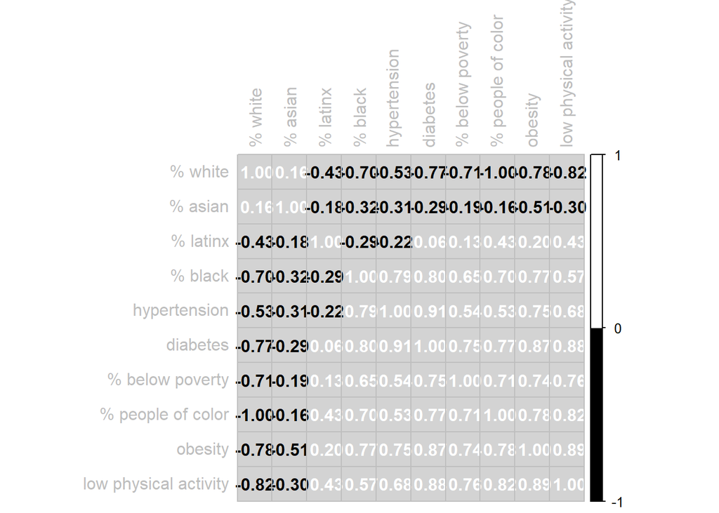

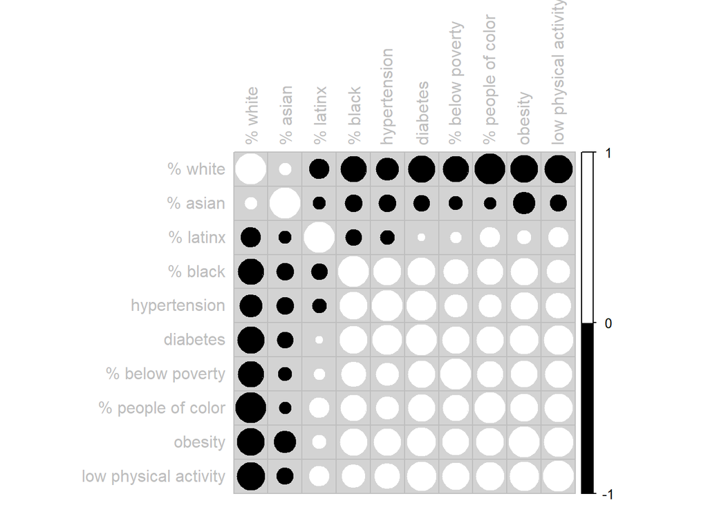

Chronic Health Prevalance Variable Names, Categories and Descriptions

| Category | Name | Variable | Description |
| --- | --- | --- | --- |
| Health outcome | Arthritis | arthritis | Model-based estimate for crude prevalence of arthritis among adults aged >=18 years |
| Health outcome | High blood pressure (HBP) | bphigh | Model-based estimate for crude prevalence of high blood pressure among adults aged >=18 years |
| Health outcome | Cancer | cancer | Model-based estimate for crude prevalence of cancer (excluding skin cancer) among adults aged >=18 years |
| Health outcome | Asthma | casthma | Model-based estimate for crude prevalence of current asthma among adults aged >=18 years |
| Health outcome | Coronary heart disease | chd | Model-based estimate for crude prevalence of coronary heart disease among adults aged >=18 years |
| Health outcome | Chronic obstructive pulmonary disease | copd | Model-based estimate for crude prevalence of chronic obstructive pulmonary disease among adults aged >=18 years |
| Health outcome | Diabetes | diabetes | Model-based estimate for crude prevalence of diagnosed diabetes among adults aged >=18 years |
| Health outcome | High cholesterol | highchol | Model-based estimate for crude prevalence of high cholesterol among adults aged >=18 years who have been screened in the past 5 years |
| Health outcome | Chronic kidney disease | kidney | Model-based estimate for crude prevalence of chronic kidney disease among adults aged >=18 years |
| Health outcome | Mental health not good | mhlth | Model-based estimate for crude prevalence of mental health not good for >=14 days among adults aged >=18 years |
| Health outcome | Physical health not good | phlth | Model-based estimate for crude prevalence of physical health not good for >=14 days among adults aged >=18 years |
| Health outcome | Stroke | stroke | Model-based estimate for crude prevalence of stroke among adults aged >=18 years |
| Health outcome | All teeth lost | teethlost | Model-based estimate for crude prevalence of all teeth lost among adults aged >=65 years |
| Prevention | Lack of health insurance | access2 | Model-based estimate for crude prevalence of current lack of health insurance among adults aged 18-64 years |
| Prevention | Taking medicine for HBP | bpmed | Model-based estimate for crude prevalence of taking medicine for high blood pressure control among adults aged >=18 years with high blood pressure |
| Prevention | Cervical cancer screening | cervical | Model-based estimate for crude prevalence of cervical cancer screening among adult women aged 21-65 years |
| Prevention | Routine checkups | checkup | Model-based estimate for crude prevalence of visits to doctor for routine checkup within the past year among adults aged >=18 years |
| Prevention | Cholesterol screening | cholscreen | Model-based estimate for crude prevalence of cholesterol screening among adults aged >=18 years |
| Prevention | Colon screening | colon_screen | Model-based estimate for crude prevalence of fecal occult blood test, sigmoidoscopy, or colonoscopy among adults aged 50-75 years |
| Prevention | Core preventative services, male | corem | Model-based estimate for crude prevalence of older adult men aged >=65 years who are up to date on a core set of clinical preventive services: Flu shot past year, PPV shot ever, Colorectal cancer scre… |
| Prevention | Core preventative services, female | corew | Model-based estimate for crude prevalence of older adult women aged >=65 years who are up to date on a core set of clinical preventive services: Flu shot past year, PPV shot ever, Colorectal cancer sc… |
| Prevention | Dental visits | dental | Model-based estimate for crude prevalence of visits to dentist or dental clinic among adults aged >=18 years |
| Prevention | Mammography | mammouse | Model-based estimate for crude prevalence of mammography use among women aged 50-74 years |
| Unhealthy behaviors | Binge drinking | binge | Model-based estimate for crude prevalence of binge drinking among adults aged >=18 years |
| Unhealthy behaviors | Smoking | csmoking | Model-based estimate for crude prevalence of current smoking among adults aged >=18 years |
| Unhealthy behaviors | No leisure-time physical activity | lpa | Model-based estimate for crude prevalence of no leisure-time physical activity among adults aged >=18 years |
| Unhealthy behaviors | Obesity | obesity | Model-based estimate for crude prevalence of obesity among adults aged >=18 years |
| Unhealthy behaviors | Sleeping less than 7 hours | sleep | Model-based estimate for crude prevalence of sleeping less than 7 hours among adults aged >=18 years |